# Midterm

Author

Everett Mahaffy

# Packages

```r
library(glue)
library(rio)
library(tidyverse)
library(purrr)
library(dplyr)
library(janitor)
library(patchwork)
```

# Part A: Data

## 1.

### Use the function above to download all of the data from the 2014-15 to 2017-18 school years and bind it into a single data frame, using a single function (i.e., one line of code). Note, this may take a minute or two to run, depending on your Internet speed.

```r
download_file <- function(year) {
  link <- glue::glue("https://www.oregon.gov/ode/educator-resources/assessment/TestResults20{year}/pagr_schools_ela_raceethnicity_{year-1}{year}.xlsx")
  rio::import(link, setclass = "tibble", na = c("-", "--", "*"))
}

df <- map_dfr(15:18, ~download_file(.x)) %>% clean_names()
```

### Conduct some basic data cleaning to make your data file look like the following.

```r
df1 <- df %>%
  filter(student_group %in% c("White", "Hispanic/Latino")) %>%
  select(1:8, starts_with("number_level")) %>%
  select(-district_id, -school_id, -subject) %>%
  drop_na(starts_with("number_level")) %>%
  pivot_longer(cols = starts_with("number_level"), names_to = "level", values_to = "n") %>%
  mutate(level = parse_number(level))
head(df1)
```

```
# A tibble: 6 × 7
  academic_year district     school        student_group grade_level level     n
  <chr>         <chr>        <chr>         <chr>         <chr>       <dbl> <dbl>
1 2014-2015     Adrian SD 61 Adrian Eleme… Hispanic/Lat… Grade 3         4     1
2 2014-2015     Adrian SD 61 Adrian Eleme… Hispanic/Lat… Grade 3         3     2
3 2014-2015     Adrian SD 61 Adrian Eleme… Hispanic/Lat… Grade 3         2     1
4 2014-2015     Adrian SD 61 Adrian Eleme… Hispanic/Lat… Grade 3         1     2
5 2014-2015     Adrian SD 61 Adrian Eleme… Hispanic/Lat… Grade 6         4     0
6 2014-2015     Adrian SD 61 Adrian Eleme… Hispanic/Lat… Grade 6         3     2
```

## 2.

### Sum the n across grades and school for each district within each academic year, student group, and level. Calculate the number of schools (unique schools listed) for each district. Also move your data to a wider format where the student groups become new columns, filled by the district n. Remove districts that did not report numbers for one or both student groups (i.e., drop missing data from the new columns). Your data frame should look like the below

```r
df2 <- df1 %>%
  group_by(district, academic_year, student_group, level) %>%
  summarize(n = (sum(n)), n_schools = length(unique(school)), .groups = "drop") %>%
  pivot_wider(names_from = student_group, values_from = n) %>%
  clean_names() %>%
  drop_na(white, hispanic_latino)
head(df2)
```

```
# A tibble: 6 × 6
  district     academic_year level n_schools hispanic_latino white
  <chr>        <chr>         <dbl>     <int>           <dbl> <dbl>
1 Adrian SD 61 2014-2015         1         1               6     8
2 Adrian SD 61 2014-2015         2         1               6    17
3 Adrian SD 61 2014-2015         3         1               6    23
4 Adrian SD 61 2014-2015         4         1               1    22
5 Amity SD 4J  2015-2016         1         3              19    61
6 Amity SD 4J  2015-2016         2         3              22    90
```

#### Note: I received a error in part B1 that was fixed by dropping NAs from the white and hispanic_latino columns.

# Part B: Achievement Disparities

```r
remotes::install_github("datalorax/gapr")
library(gapr)
```

## 1.

### Estimate the average achievement differences in terms of an effect size for every school district in the state that reported data on both student groups (i.e., using the data we created above), for each academic year. Conduct this analysis twice, once using group_by() |> nest() and map() and once using nest_by() |> summarize().

#### Approach 1

```r
b1a <- df2 %>%
  group_by(district, academic_year) %>%
  nest() %>%
  mutate(effect_size = map(data, ~estimate_v(.x, "white", "hispanic_latino"))) %>%
  unnest(effect_size)

head(b1a)
```

```
# A tibble: 6 × 6
# Groups:   district, academic_year [6]
  district     academic_year data               auc      v    v_se
  <chr>        <chr>         <list>           <dbl>  <dbl>   <dbl>
1 Adrian SD 61 2014-2015     <tibble [4 × 4]> 0.282 -0.814 0.0728
2 Amity SD 4J  2015-2016     <tibble [4 × 4]> 0.432 -0.243 0.0210
3 Amity SD 4J  2017-2018     <tibble [4 × 4]> 0.469 -0.111 0.0207
4 Annex SD 29  2016-2017     <tibble [4 × 4]> 0.588  0.313 0.449
5 Astoria SD 1 2014-2015     <tibble [4 × 4]> 0.383 -0.419 0.00910
6 Astoria SD 1 2015-2016     <tibble [4 × 4]> 0.349 -0.547 0.00862
```

#### Approach 2

```r
b1b <- df2 %>%
  nest_by(district, academic_year) %>%
  summarize(effect_size = estimate_v(data, "white", "hispanic_latino")) %>%
  unnest(effect_size)

head(b1b)
```

```
# A tibble: 6 × 5
# Groups:   district, academic_year [6]
  district     academic_year   auc      v    v_se
  <chr>        <chr>         <dbl>  <dbl>   <dbl>
1 Adrian SD 61 2014-2015     0.282 -0.814 0.0728
2 Amity SD 4J  2015-2016     0.432 -0.243 0.0210
3 Amity SD 4J  2017-2018     0.469 -0.111 0.0207
4 Annex SD 29  2016-2017     0.588  0.313 0.449
5 Astoria SD 1 2014-2015     0.383 -0.419 0.00910
6 Astoria SD 1 2015-2016     0.349 -0.547 0.00862
```

## 2.

### Reproduce the following plot to confirm that the estimates are equivalent across methods.

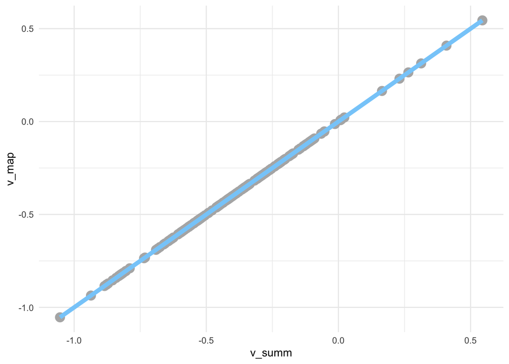

```r
b1a <- b1a %>% rename(v_map = v)
b1b <- b1b %>% rename(v_summ = v)
combined <- full_join(b1a, b1b, by = c("district", "academic_year"))
ggplot(combined, aes (x=v_summ, y=v_map)) +
  geom_point(size = 4, color = "gray70") +
  geom_line(size = 2, color = "lightskyblue") +
  theme_minimal()
```

## 3.

### The plot below shows the achievement difference estimates for one school district across years. Produce a similar plot to the below for each of the first 100 school districts. Once you’ve created all the plots, reproduce them again using an alternative method. Make sure you don’t miss the caption noting the number of schools in the district.

```r
# "v" values were in a different object so I have to join them in order to have n_schools and v in the same dataframe. also grouping by and summarizing across levels since we don't use them here.

b3data <- df2 %>%
  group_by(district, academic_year) %>%
  summarize(white = sum(white), hispanic_latino = sum(hispanic_latino), n_schools = mean(n_schools), .groups = "drop") %>%
  full_join(b1a) %>%
  select(-data) %>%
  rename(v = v_map)

# selecting first 100 unique districts

dists <- unique(b3data$district)[1:100]

plot_data <- b3data %>%
  filter(district %in% dists)
```

#### Method 1: Row-wise/Nest-by

```r
plots <- plot_data %>%
  nest_by(district) %>%
  mutate(
    plot = list(
    ggplot(data, aes(x = academic_year, y = v)) +
      geom_hline(yintercept = 0, color = "red", size = 0.5) +
      geom_line(aes(group = 1), size = 0.5, alpha = .5) +
      geom_point(aes(color = ifelse(v >= 0, "positive", "negative"))) +
      geom_errorbar(aes(ymin = v - v_se, ymax = v + v_se), width = 0.1) +
      scale_color_manual(values = c(positive = "deepskyblue", negative = "hotpink")) +
      theme_minimal() +
      labs(y = "Average achievement difference (SD units)", x = "School year",
           title = glue("Achievement Gap Estimates: {district}"),
           caption = glue("Note: district included {data$n_schools} schools"),
           subtitle = "Negative values (pink) indicate White students have higher average achievement \n Positive values (blue) indicate Hispanic/Latino students have higher average achievement"
    ) +
      theme(legend.position = "none")
    ))
```

#### Method 2: lapply

```r
plot_data_split <- split(plot_data, plot_data$district)
lapply_plots <- lapply(plot_data_split, function(x) {
    ggplot(x, aes(x = academic_year, y = v)) +
      geom_hline(yintercept = 0, color = "red", size = 0.5) +
      geom_line(aes(group = 1), size = 0.5, alpha = .5) +
      geom_point(aes(color = ifelse(v >= 0, "positive", "negative"))) +
      geom_errorbar(aes(ymin = v - v_se, ymax = v + v_se), width = 0.1) +
      scale_color_manual(values = c(positive = "deepskyblue", negative = "hotpink")) +
      theme_minimal() +
      labs(y = "Average achievement difference (SD units)", x = "School year",
           title = glue("Achievement Gap Estimates: {x$district}"),
           caption = glue("Note: district included {x$n_schools} schools"),
           subtitle = "Negative values (pink) indicate White students have higher average achievement \n Positive values (blue) indicate Hispanic/Latino students have higher average achievement"
    ) +
      theme(legend.position = "none")
})
```

#### Method 3: Map

```r
map_plots <- plot_data %>%
  group_by(district) %>%
  nest() %>%
    mutate(
    plots = pmap(list(district, data),
    ~ggplot(..2, aes(x = academic_year, y = v)) +
      geom_hline(yintercept = 0, color = "red", size = 0.5) +
      geom_line(aes(group = 1), size = 0.5, alpha = .5) +
      geom_point(aes(color = ifelse(v >= 0, "positive", "negative"))) +
      geom_errorbar(aes(ymin = v - v_se, ymax = v + v_se), width = 0.1) +
      scale_color_manual(values = c(positive = "deepskyblue", negative = "hotpink")) +
      theme_minimal() +
      theme(legend.position = "none") +
      labs(y = "Average achievement difference (SD units)", x = "School year",
           title = glue("Achievement Gap Estimates: {..1}"),
           caption = glue("Note: district included {..2$n_schools} schools"),
           subtitle = "Negative values (pink) indicate White students have higher average achievement \n Positive values (blue) indicate Hispanic/Latino students have higher average achievement"
    )))
```

#### Example Plot

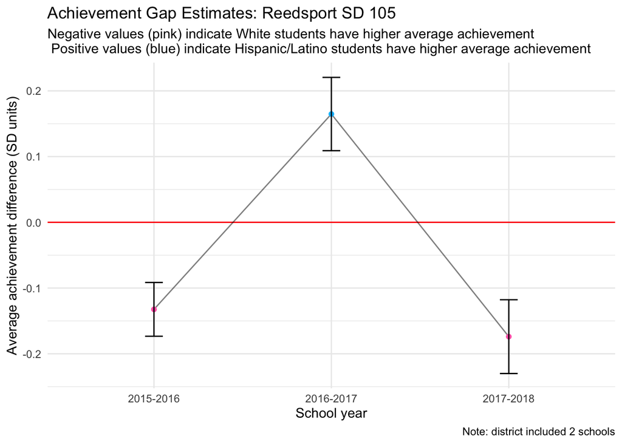

```r
plots$plot[[58]]
```

## 4.

### Save the plots into a “plots” directory. Make sure the file names are meaningful.

```r
fs::dir_create(here::here("plots", "districts"))
files <- str_replace_all(
  tolower(plots$district),
  " ",
  "-"
)
paths <- here::here("plots", "districts", glue("{files}.png"))
head(paths)
```

```
[1] "/Users/everett/Desktop/EDLD653_Midterm/plots/districts/adrian-sd-61.png"
[2] "/Users/everett/Desktop/EDLD653_Midterm/plots/districts/amity-sd-4j.png"
[3] "/Users/everett/Desktop/EDLD653_Midterm/plots/districts/annex-sd-29.png"
[4] "/Users/everett/Desktop/EDLD653_Midterm/plots/districts/astoria-sd-1.png"
[5] "/Users/everett/Desktop/EDLD653_Midterm/plots/districts/bandon-sd-54.png"
[6] "/Users/everett/Desktop/EDLD653_Midterm/plots/districts/banks-sd-13.png"
```

```r
walk2(plots$plot, paths, ~ggsave(.y, .x))
```

# Extra Credit

### From question B.3. above, create a third set of plots that puts together each of the pairs of plots from the two methods to confirm that the plots were produced identically by both methods.

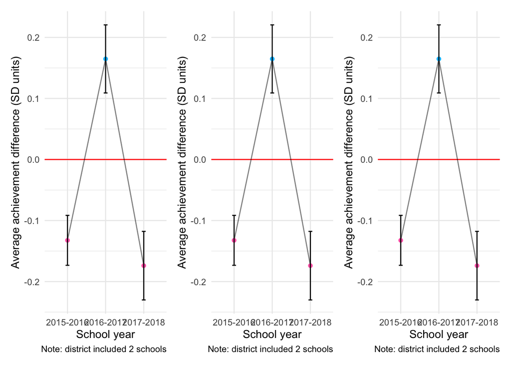

```r
plots1 <- map(plots$plot, ~.x + theme(plot.title = element_blank(), plot.subtitle = element_blank()))
plots2 <- map(lapply_plots, ~.x + theme(plot.title = element_blank(), plot.subtitle = element_blank()))
plots3 <- map(map_plots$plots, ~.x + theme(plot.title = element_blank(), plot.subtitle = element_blank()))

# removed plot titles to improve combined plot readability

extra <- pmap(list(plots1, plots2, plots3), ~(..1 + ..2 + ..3))

extra[[58]]
```